# Slides

Black Flamingos  
November 2017

### Cleaning/Imputing

Dealing with Missing Data

- Straight mode imputing for most
- Other-column-dependent mode imputing otherwise

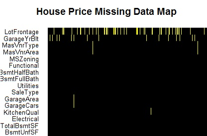

### Cleaning/Imputing

Imputing Lot Frontage

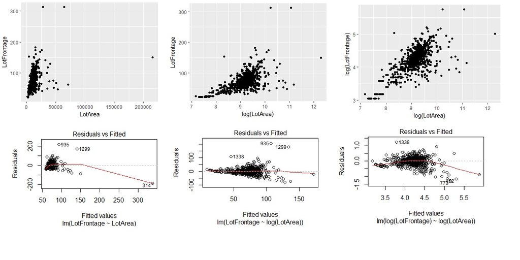

### Outliers

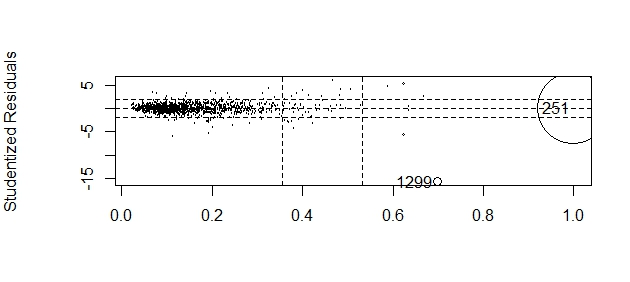

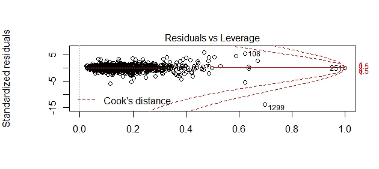

### Releveling

Goal: Improve predictions for “average” houses at the expense of predictions for “rare” houses (linear only)

Inspecting a categorical feature with rare levels (<1% of data):

```
# A tibble: 6 x 2
  Heating `n()`
   <fctr> <int>
1   Floor     1
2    GasA  1428
3    GasW    18
4    Grav     7
5    OthW     2
6    Wall     4
```

### Releveling

Solution:

```r
levels(houses.train$Heating)[levels(houses.train$Heating) %in%
                               c("Floor", "Grav", "OthW", "Wall")] <- "Other"
```

```
# A tibble: 3 x 2
  Heating `n()`
   <fctr> <int>
1   Other    14
2    GasA  1428
3    GasW    18
```

### Releveling

Additional problems addressed:

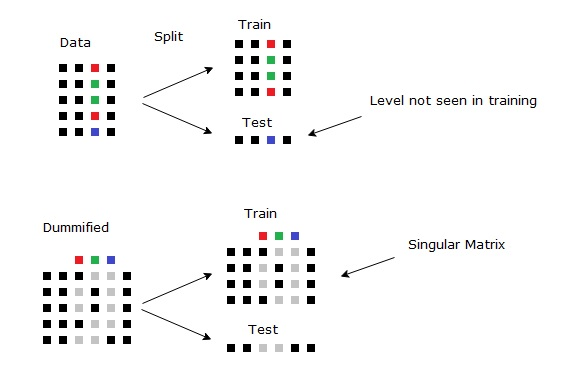

### Feature Engineering

a.k.a. Reading about real estate

- Garage interaction: GarageQual * GarageCars
- Total bathrooms: FullBath + HalfBath + BsmtFullBath + BsmtHalfBath
- Average room size: GrLivArea / TotRmsAbvGrd
- Bathroom to room ratio: (FullBath + HalfBath) / BedroomAbvGr
- Comparative size of living area: GrLivArea / mean(GrLivArea)
- Landscape-ability interaction: LotShape, LotContour

### Splitting and Encoding

Treat data for tree-based and linear-based models separately:

For tree-based models:

- Split Kaggle train data into 'private train' and 'private test' (80/20)
- Label-count encode

For linear-based models:

- Encoding: one-hot encoding

### Modeling Process

Individual models

- Grid search to tune hyper parameters (if applicable)
- Fit model to private train set with tuned parameters
- Predict on private test set; if okay, proceed…
- Fit new model to Kaggle train set with private train hyperparameters
- Cross-validate on Kaggle train set; if okay, proceed…
- Predict on Kaggle test set
- Submit to Kaggle; deal with feelings of mediocrity

### Models Trained

In R and Python:

- Multiple linear, spline
- Ridge, LASSO, elastic net
- Decision tree (basic)
- Random forest
- Gradient boosted forest
- XGBoosted forest

### Stacking...then averaging

Following Zeyu:

- 1 Spline
- 1 XGBoost
- Meta model: GBM

In the end, averaging the predictions for our spline and our XGBoost was better than stacking, so that's what we ended with.

### Discussion

Results and lessons

- Best Kaggle score/rank: .1218, 639/2288
- Git checkout is amazing!!